# Tasks

Camille Benoit

03/12/2020

```r
.libPaths("C:/Program Files (x86)/R/win-library/4.0")
```

# Task number 1

### Function + for loop

Instructions are to write a function that :

- Takes data frame, row selection and column selection as arguments
- Subsets data according to the given selections. Possible selections are: by index/indexes, by name/names, by logical vector
- For each column of the subseted data performs some computations: for numeric data – any of sum(), mean(), sd(), etc and for non-numeric data (characters and logical vectors, factors) – frequency table
- Returns an output as a data frame and calculation results as a list (subset + summary)

Here is what I wrote for this function.

```r
my_function <- function(data, rows, columns){
  subset <- data[rows, columns, drop = FALSE]
  res <- list(subset)
  for (col in colnames(subset)){
    if (is.numeric(subset[[col]])){
      meancol <- list(mean(subset[[col]]))
      res <- c(res, meancol)
    } else {
      tablecol <- list(table(subset[[col]]))
      res <- c(res, tablecol)
    }
  }
  names(res) <- c("Subset", colnames(subset))
  res
}
```

I used iris dataframe to do some tests.

```r
head(iris)
```

```
##   Sepal.Length Sepal.Width Petal.Length Petal.Width Species
## 1          5.1         3.5          1.4         0.2  setosa
## 2          4.9         3.0          1.4         0.2  setosa
## 3          4.7         3.2          1.3         0.2  setosa
## 4          4.6         3.1          1.5         0.2  setosa
## 5          5.0         3.6          1.4         0.2  setosa
## 6          5.4         3.9          1.7         0.4  setosa
```

Here are my results :

```r
my_function(iris, 1:50 , c("Petal.Length","Sepal.Width", "Species"))
```

```
## $Subset
##    Petal.Length Sepal.Width Species
## 1           1.4         3.5  setosa
## 2           1.4         3.0  setosa
## 3           1.3         3.2  setosa
## 4           1.5         3.1  setosa
## 5           1.4         3.6  setosa
## 6           1.7         3.9  setosa
## 7           1.4         3.4  setosa
## 8           1.5         3.4  setosa
## 9           1.4         2.9  setosa
## 10          1.5         3.1  setosa
## 11          1.5         3.7  setosa
## 12          1.6         3.4  setosa
## 13          1.4         3.0  setosa
```

[output cut: 48 more lines]

```r
my_function(iris, c(1:25,55:65,110:122) , c(4,2,5))
```

```
## $Subset
##     Petal.Width Sepal.Width    Species
## 1           0.2         3.5     setosa
## 2           0.2         3.0     setosa
## 3           0.2         3.2     setosa
## 4           0.2         3.1     setosa
## 5           0.2         3.6     setosa
## 6           0.4         3.9     setosa
## 7           0.3         3.4     setosa
## 8           0.2         3.4     setosa
## 9           0.2         2.9     setosa
## 10          0.1         3.1     setosa
## 11          0.2         3.7     setosa
## 12          0.2         3.4     setosa
## 13          0.1         3.0     setosa
```

[output cut: 47 more lines]

```r
my_function(iris, 45:102 , 3:5)
```

```
## $Subset
##     Petal.Length Petal.Width    Species
## 45           1.9         0.4     setosa
## 46           1.4         0.3     setosa
## 47           1.6         0.2     setosa
## 48           1.4         0.2     setosa
## 49           1.5         0.2     setosa
## 50           1.4         0.2     setosa
## 51           4.7         1.4 versicolor
## 52           4.5         1.5 versicolor
## 53           4.9         1.5 versicolor
## 54           4.0         1.3 versicolor
## 55           4.6         1.5 versicolor
## 56           4.5         1.3 versicolor
## 57           4.7         1.6 versicolor
```

[output cut: 56 more lines]

# Task number 2

### Function + looping function

Instructions for this task are to rewrite my previous function using *apply(), to add formal argument to split the data and to add calculation function as a formal argument to the function.

Here is what I wrote.

```r
my_new_function <- function(data, rows, columns, f, splt){
  subset <- data[rows, columns, drop = FALSE]
  spltcol <- data[rows, splt]
  concat_subset <- cbind(subset, spltcol)
  res <- list(subset)
  for (col in colnames(subset)){
    if (is.numeric(subset[[col]])){
      newres <- list(tapply(X = concat_subset[[col]], INDEX = spltcol, FUN = f))
    }else{
      newres <- list(table(subset[[col]]))
    }
    res <- c(res, newres)
  }
  names(res) <- c("Subset" ,colnames(subset))
  res
}
```

And some examples :

```r
my_new_function(iris, 1:150, 2:4, sum, "Species")
```

```
## $Subset
##     Sepal.Width Petal.Length Petal.Width
## 1           3.5          1.4         0.2
## 2           3.0          1.4         0.2
## 3           3.2          1.3         0.2
## 4           3.1          1.5         0.2
## 5           3.6          1.4         0.2
## 6           3.9          1.7         0.4
## 7           3.4          1.4         0.3
## 8           3.4          1.5         0.2
## 9           2.9          1.4         0.2
## 10          3.1          1.5         0.1
## 11          3.7          1.5         0.2
## 12          3.4          1.6         0.2
## 13          3.0          1.4         0.1
```

[output cut: 149 more lines]

```r
my_new_function(iris, 1:75, 1:3, mean, 5)
```

```
## $Subset
##    Sepal.Length Sepal.Width Petal.Length
## 1           5.1         3.5          1.4
## 2           4.9         3.0          1.4
## 3           4.7         3.2          1.3
## 4           4.6         3.1          1.5
## 5           5.0         3.6          1.4
## 6           5.4         3.9          1.7
## 7           4.6         3.4          1.4
## 8           5.0         3.4          1.5
## 9           4.4         2.9          1.4
## 10          4.9         3.1          1.5
## 11          5.4         3.7          1.5
## 12          4.8         3.4          1.6
## 13          4.8         3.0          1.4
```

[output cut: 74 more lines]

```r
my_new_function(iris, 6:23, c(1,2), max, 5)
```

```
## $Subset
##    Sepal.Length Sepal.Width
## 6           5.4         3.9
## 7           4.6         3.4
## 8           5.0         3.4
## 9           4.4         2.9
## 10          4.9         3.1
## 11          5.4         3.7
## 12          4.8         3.4
## 13          4.8         3.0
## 14          4.3         3.0
## 15          5.8         4.0
## 16          5.7         4.4
## 17          5.4         3.9
## 18          5.1         3.5
## 19          5.7         3.8
## 20          5.1         3.8
## 21          5.4         3.4
## 22          5.1         3.7
## 23          4.6         3.6
##
## $Sepal.Length
##     setosa versicolor  virginica
##        5.8         NA         NA
##
## $Sepal.Width
##     setosa versicolor  virginica
##        4.4         NA         NA
```

# Task 3

### Weather’s data tidying and cleaning

What I have to do for this task is to explore, tidy and prepare the dataset weather.rds

#### Raw data

Here is the raw data, with no modification (first 15 rows).

```r
weather <- readRDS("weather.rds")
head(weather, n=15)
```

```
##     X year month                   measure    X1    X2    X3    X4    X5    X6
## 1   1 2014    12          Max.TemperatureF    64    42    51    43    42    45
## 2   2 2014    12         Mean.TemperatureF    52    38    44    37    34    42
## 3   3 2014    12          Min.TemperatureF    39    33    37    30    26    38
## 4   4 2014    12            Max.Dew.PointF    46    40    49    24    37    45
## 5   5 2014    12            MeanDew.PointF    40    27    42    21    25    40
## 6   6 2014    12             Min.DewpointF    26    17    24    13    12    36
## 7   7 2014    12              Max.Humidity    74    92   100    69    85   100
## 8   8 2014    12             Mean.Humidity    63    72    79    54    66    93
## 9   9 2014    12              Min.Humidity    52    51    57    39    47    85
## 10 10 2014    12  Max.Sea.Level.PressureIn 30.45 30.71  30.4 30.56 30.68 30.42
## 11 11 2014    12 Mean.Sea.Level.PressureIn 30.13 30.59 30.07 30.33 30.59 30.24
## 12 12 2014    12  Min.Sea.Level.PressureIn 30.01  30.4 29.87 30.09 30.45 30.16
## 13 13 2014    12       Max.VisibilityMiles    10    10    10    10    10    10
## 14 14 2014    12      Mean.VisibilityMiles    10     8     5    10    10     4
```

[output cut: 49 more lines]

#### Instruction list

I see that we have two issues with our raw data.

1/ Our variables are in a column named “measure” and Column headers are values (X1 -> X31) instead of variable names

2/ The first column with only index is useless.

To deal with that I will use tidyverse library.

```r
library(tidyverse)
```

As we are working with weather and already have “Month” and “Year” column, I will assume that X1…X31 correspond to days. After exploring data, I saw that 31st days corresponding to months with only 30 days contain NA values.

First, I remove the first column which is useless.

```r
weather2 <- weather[, -1]
head(weather2, n=10)
```

```
##    year month                  measure    X1    X2   X3    X4    X5    X6    X7
## 1  2014    12         Max.TemperatureF    64    42   51    43    42    45    38
## 2  2014    12        Mean.TemperatureF    52    38   44    37    34    42    30
## 3  2014    12         Min.TemperatureF    39    33   37    30    26    38    21
## 4  2014    12           Max.Dew.PointF    46    40   49    24    37    45    36
## 5  2014    12           MeanDew.PointF    40    27   42    21    25    40    20
## 6  2014    12            Min.DewpointF    26    17   24    13    12    36    -3
## 7  2014    12             Max.Humidity    74    92  100    69    85   100    92
## 8  2014    12            Mean.Humidity    63    72   79    54    66    93    61
## 9  2014    12             Min.Humidity    52    51   57    39    47    85    29
## 10 2014    12 Max.Sea.Level.PressureIn 30.45 30.71 30.4 30.56 30.68 30.42 30.69
##       X8    X9   X10   X11   X12   X13   X14   X15   X16   X17   X18   X19
## 1     29    49    48    39    39    42    45    42    44    49    44    37
## 2     24    39    43    36    35    37    39    37    40    45    40    33
## 3     18    29    38    32    31    32    33    32    35    41    36    29
```

[output cut: 18 more lines]

Then I gather all measurements by days and I will delete NA values (na.rm = TRUE).

```r
weather_gather <- gather(weather2, day, measurement_value, X1:X31, na.rm = TRUE)
head(weather_gather, n = 10)
```

```
##    year month                  measure day measurement_value
## 1  2014    12         Max.TemperatureF  X1                64
## 2  2014    12        Mean.TemperatureF  X1                52
## 3  2014    12         Min.TemperatureF  X1                39
## 4  2014    12           Max.Dew.PointF  X1                46
## 5  2014    12           MeanDew.PointF  X1                40
## 6  2014    12            Min.DewpointF  X1                26
## 7  2014    12             Max.Humidity  X1                74
## 8  2014    12            Mean.Humidity  X1                63
## 9  2014    12             Min.Humidity  X1                52
## 10 2014    12 Max.Sea.Level.PressureIn  X1             30.45
```

```r
tail(weather_gather, n= 10)
```

```
##      year month              measure day measurement_value
## 8813 2015    10  Max.VisibilityMiles X31                10
## 8814 2015    10 Mean.VisibilityMiles X31                10
## 8815 2015    10  Min.VisibilityMiles X31                10
## 8816 2015    10    Max.Wind.SpeedMPH X31                13
## 8817 2015    10   Mean.Wind.SpeedMPH X31                 7
## 8818 2015    10    Max.Gust.SpeedMPH X31                17
## 8819 2015    10      PrecipitationIn X31              0.00
## 8820 2015    10           CloudCover X31                 4
## 8821 2015    10               Events X31
## 8822 2015    10       WindDirDegrees X31               224
```

I spread the column measure to have a column for each measure.

```r
tidy_weather <- spread(weather_gather, measure, measurement_value)
head(tidy_weather, n = 10)
```

```
##    year month day CloudCover    Events Max.Dew.PointF Max.Gust.SpeedMPH
## 1  2014    12  X1          6      Rain             46                29
## 2  2014    12 X10          8      Rain             45                29
## 3  2014    12 X11          8 Rain-Snow             37                28
## 4  2014    12 X12          7      Snow             28                21
## 5  2014    12 X13          5                       28                23
## 6  2014    12 X14          4                       29                20
## 7  2014    12 X15          2                       33                21
## 8  2014    12 X16          8      Rain             42                10
## 9  2014    12 X17          8      Rain             46                26
## 10 2014    12 X18          7      Rain             34                30
##    Max.Humidity Max.Sea.Level.PressureIn Max.TemperatureF Max.VisibilityMiles
## 1            74                    30.45               64                  10
## 2           100                    29.58               48                  10
## 3            92                    29.81               39                  10
```

[output cut: 51 more lines]

Finally I have in my dataset :

- Each object / observation is presented in a different row
- Each measured variable is presented in a different column
- Each cell – an intersection of given row and column – presents a value of the given variable for the given observation

Here is the **final instruction list** :

```r
weather2 <- weather[, -1]
weather_gather <- gather(weather2, day, measurement_value, X1:X31, na.rm = TRUE)
tidy_weather <- spread(weather_gather, measure, measurement_value)
```

#### Tidy data

```r
head(tidy_weather)
```

```
##   year month day CloudCover    Events Max.Dew.PointF Max.Gust.SpeedMPH
## 1 2014    12  X1          6      Rain             46                29
## 2 2014    12 X10          8      Rain             45                29
## 3 2014    12 X11          8 Rain-Snow             37                28
## 4 2014    12 X12          7      Snow             28                21
## 5 2014    12 X13          5                       28                23
## 6 2014    12 X14          4                       29                20
##   Max.Humidity Max.Sea.Level.PressureIn Max.TemperatureF Max.VisibilityMiles
## 1           74                    30.45               64                  10
## 2          100                    29.58               48                  10
## 3           92                    29.81               39                  10
## 4           85                    29.88               39                  10
## 5           75                    29.86               42                  10
## 6           82                    29.91               45                  10
##   Max.Wind.SpeedMPH Mean.Humidity Mean.Sea.Level.PressureIn Mean.TemperatureF
```

[output cut: 27 more lines]

#### Cleaning and preparing the data

First thing I’m going to delete the “X” before the number of days in day column and concatenate day, month and year column into on column for date. I need to change the format to date so it will not be a string anymore.

```r
cleaned_weather <- tidy_weather
cleaned_weather[['day']] <- str_replace(cleaned_weather[['day']], "X", "")
cleaned_weather <- unite(cleaned_weather, date, year, month, day, sep = "/")
cleaned_weather[['date']] <- as.Date(cleaned_weather[['date']], "%Y/%m/%d")
head(cleaned_weather)
```

```
##         date CloudCover    Events Max.Dew.PointF Max.Gust.SpeedMPH Max.Humidity
## 1 2014-12-01          6      Rain             46                29           74
## 2 2014-12-10          8      Rain             45                29          100
## 3 2014-12-11          8 Rain-Snow             37                28           92
## 4 2014-12-12          7      Snow             28                21           85
## 5 2014-12-13          5                       28                23           75
## 6 2014-12-14          4                       29                20           82
##   Max.Sea.Level.PressureIn Max.TemperatureF Max.VisibilityMiles
## 1                    30.45               64                  10
## 2                    29.58               48                  10
## 3                    29.81               39                  10
## 4                    29.88               39                  10
## 5                    29.86               42                  10
## 6                    29.91               45                  10
##   Max.Wind.SpeedMPH Mean.Humidity Mean.Sea.Level.PressureIn Mean.TemperatureF
```

[output cut: 27 more lines]

Also, I saw that there are “T” in precipitation column. It means “trace” and we can change this by 0.

```r
cleaned_weather[['PrecipitationIn']] <- str_replace(cleaned_weather[['PrecipitationIn']], "T", "0.00")
head(cleaned_weather)
```

```
##         date CloudCover    Events Max.Dew.PointF Max.Gust.SpeedMPH Max.Humidity
## 1 2014-12-01          6      Rain             46                29           74
## 2 2014-12-10          8      Rain             45                29          100
## 3 2014-12-11          8 Rain-Snow             37                28           92
## 4 2014-12-12          7      Snow             28                21           85
## 5 2014-12-13          5                       28                23           75
## 6 2014-12-14          4                       29                20           82
##   Max.Sea.Level.PressureIn Max.TemperatureF Max.VisibilityMiles
## 1                    30.45               64                  10
## 2                    29.58               48                  10
## 3                    29.81               39                  10
## 4                    29.88               39                  10
## 5                    29.86               42                  10
## 6                    29.91               45                  10
##   Max.Wind.SpeedMPH Mean.Humidity Mean.Sea.Level.PressureIn Mean.TemperatureF
```

[output cut: 27 more lines]

And finally change our values’ format to numeric ones so I can use summary function after. To do so, I need to first to switch Events and CloudCover columns.

```r
cleaned_weather <- select(cleaned_weather, date, Events, CloudCover:WindDirDegrees)
cleaned_weather[, 3:23] <- sapply(cleaned_weather[, 3:23], as.numeric)
head(cleaned_weather)
```

```
##         date    Events CloudCover Max.Dew.PointF Max.Gust.SpeedMPH Max.Humidity
## 1 2014-12-01      Rain          6             46                29           74
## 2 2014-12-10      Rain          8             45                29          100
## 3 2014-12-11 Rain-Snow          8             37                28           92
## 4 2014-12-12      Snow          7             28                21           85
## 5 2014-12-13                    5             28                23           75
## 6 2014-12-14                    4             29                20           82
##   Max.Sea.Level.PressureIn Max.TemperatureF Max.VisibilityMiles
## 1                    30.45               64                  10
## 2                    29.58               48                  10
## 3                    29.81               39                  10
## 4                    29.88               39                  10
## 5                    29.86               42                  10
## 6                    29.91               45                  10
##   Max.Wind.SpeedMPH Mean.Humidity Mean.Sea.Level.PressureIn Mean.TemperatureF
```

[output cut: 27 more lines]

Now that everything is fine I can check if there are missing values.

```r
summary(cleaned_weather)
```

```
##       date               Events            CloudCover    Max.Dew.PointF
##  Min.   :2014-12-01   Length:366         Min.   :0.000   Min.   :-6.00
##  1st Qu.:2015-03-02   Class :character   1st Qu.:3.000   1st Qu.:32.00
##  Median :2015-06-01   Mode  :character   Median :5.000   Median :47.50
##  Mean   :2015-06-01                      Mean   :4.708   Mean   :45.48
##  3rd Qu.:2015-08-31                      3rd Qu.:7.000   3rd Qu.:61.00
##  Max.   :2015-12-01                      Max.   :8.000   Max.   :75.00
##
##  Max.Gust.SpeedMPH  Max.Humidity     Max.Sea.Level.PressureIn Max.TemperatureF
##  Min.   : 0.00     Min.   :  39.00   Min.   :29.58            Min.   :18.00
##  1st Qu.:21.00     1st Qu.:  73.25   1st Qu.:30.00            1st Qu.:42.00
##  Median :25.50     Median :  86.00   Median :30.14            Median :60.00
##  Mean   :26.99     Mean   :  85.69   Mean   :30.16            Mean   :58.93
##  3rd Qu.:31.25     3rd Qu.:  93.00   3rd Qu.:30.31            3rd Qu.:76.00
##  Max.   :94.00     Max.   :1000.00   Max.   :30.88            Max.   :96.00
##  NA's   :6
##  Max.VisibilityMiles Max.Wind.SpeedMPH Mean.Humidity
##  Min.   : 2.000      Min.   : 8.00     Min.   :28.00
##  1st Qu.:10.000      1st Qu.:16.00     1st Qu.:56.00
##  Median :10.000      Median :20.00     Median :66.00
##  Mean   : 9.907      Mean   :20.62     Mean   :66.02
##  3rd Qu.:10.000      3rd Qu.:24.00     3rd Qu.:76.75
##  Max.   :10.000      Max.   :38.00     Max.   :98.00
##
##  Mean.Sea.Level.PressureIn Mean.TemperatureF Mean.VisibilityMiles
##  Min.   :29.49             Min.   : 8.00     Min.   :-1.000
##  1st Qu.:29.87             1st Qu.:36.25     1st Qu.: 8.000
##  Median :30.03             Median :53.50     Median :10.000
##  Mean   :30.04             Mean   :51.40     Mean   : 8.861
##  3rd Qu.:30.19             3rd Qu.:68.00     3rd Qu.:10.000
##  Max.   :30.77             Max.   :84.00     Max.   :10.000
##
##  Mean.Wind.SpeedMPH MeanDew.PointF   Min.DewpointF     Min.Humidity
##  Min.   : 4.00      Min.   :-11.00   Min.   :-18.00   Min.   :16.00
##  1st Qu.: 8.00      1st Qu.: 24.00   1st Qu.: 16.25   1st Qu.:35.00
##  Median :10.00      Median : 41.00   Median : 35.00   Median :46.00
##  Mean   :10.68      Mean   : 38.96   Mean   : 32.25   Mean   :48.31
##  3rd Qu.:13.00      3rd Qu.: 56.00   3rd Qu.: 51.00   3rd Qu.:60.00
##  Max.   :22.00      Max.   : 71.00   Max.   : 68.00   Max.   :96.00
##
##  Min.Sea.Level.PressureIn Min.TemperatureF Min.VisibilityMiles PrecipitationIn
##  Min.   :29.16            Min.   :-3.00    Min.   : 0.000      Min.   :0.0000
##  1st Qu.:29.76            1st Qu.:30.00    1st Qu.: 2.000      1st Qu.:0.0000
##  Median :29.94            Median :46.00    Median :10.000      Median :0.0000
##  Mean   :29.93            Mean   :43.33    Mean   : 6.716      Mean   :0.1016
##  3rd Qu.:30.09            3rd Qu.:60.00    3rd Qu.:10.000      3rd Qu.:0.0400
##  Max.   :30.64            Max.   :74.00    Max.   :10.000      Max.   :2.9000
##
##  WindDirDegrees
##  Min.   :  1.0
##  1st Qu.:113.0
##  Median :222.0
##  Mean   :200.1
##  3rd Qu.:275.0
##  Max.   :360.0
##
```

We can see that there are 6 NA values in Max.Gust.SpeedMPH, we know thanks to head that there are Empty values in Events too. We can also see that there is a mistake in Max.Humidity column. Humidity is measured by % so the maximum should be 100 instead of 1000.

```r
cleaned_weather[["Events"]][cleaned_weather[["Events"]] == ""] <- "none"
cleaned_weather[["Max.Humidity"]][cleaned_weather[["Max.Humidity"]] == 1000] <- 100
```

As I don’t know what to do with NA values in Max.Gust.SpeedMPH I decided to leave it like that.

#### The code book with final cleaned dataset

```r
head(cleaned_weather)
```

```
##         date    Events CloudCover Max.Dew.PointF Max.Gust.SpeedMPH Max.Humidity
## 1 2014-12-01      Rain          6             46                29           74
## 2 2014-12-10      Rain          8             45                29          100
## 3 2014-12-11 Rain-Snow          8             37                28           92
## 4 2014-12-12      Snow          7             28                21           85
## 5 2014-12-13      none          5             28                23           75
## 6 2014-12-14      none          4             29                20           82
##   Max.Sea.Level.PressureIn Max.TemperatureF Max.VisibilityMiles
## 1                    30.45               64                  10
## 2                    29.58               48                  10
## 3                    29.81               39                  10
## 4                    29.88               39                  10
## 5                    29.86               42                  10
## 6                    29.91               45                  10
##   Max.Wind.SpeedMPH Mean.Humidity Mean.Sea.Level.PressureIn Mean.TemperatureF
```

[output cut: 27 more lines]

```r
summary(cleaned_weather)
```

```
##       date               Events            CloudCover    Max.Dew.PointF
##  Min.   :2014-12-01   Length:366         Min.   :0.000   Min.   :-6.00
##  1st Qu.:2015-03-02   Class :character   1st Qu.:3.000   1st Qu.:32.00
##  Median :2015-06-01   Mode  :character   Median :5.000   Median :47.50
##  Mean   :2015-06-01                      Mean   :4.708   Mean   :45.48
##  3rd Qu.:2015-08-31                      3rd Qu.:7.000   3rd Qu.:61.00
##  Max.   :2015-12-01                      Max.   :8.000   Max.   :75.00
##
##  Max.Gust.SpeedMPH  Max.Humidity    Max.Sea.Level.PressureIn Max.TemperatureF
##  Min.   : 0.00     Min.   : 39.00   Min.   :29.58            Min.   :18.00
##  1st Qu.:21.00     1st Qu.: 73.25   1st Qu.:30.00            1st Qu.:42.00
##  Median :25.50     Median : 86.00   Median :30.14            Median :60.00
##  Mean   :26.99     Mean   : 83.23   Mean   :30.16            Mean   :58.93
##  3rd Qu.:31.25     3rd Qu.: 93.00   3rd Qu.:30.31            3rd Qu.:76.00
##  Max.   :94.00     Max.   :100.00   Max.   :30.88            Max.   :96.00
##  NA's   :6
##  Max.VisibilityMiles Max.Wind.SpeedMPH Mean.Humidity
##  Min.   : 2.000      Min.   : 8.00     Min.   :28.00
##  1st Qu.:10.000      1st Qu.:16.00     1st Qu.:56.00
##  Median :10.000      Median :20.00     Median :66.00
##  Mean   : 9.907      Mean   :20.62     Mean   :66.02
##  3rd Qu.:10.000      3rd Qu.:24.00     3rd Qu.:76.75
##  Max.   :10.000      Max.   :38.00     Max.   :98.00
##
##  Mean.Sea.Level.PressureIn Mean.TemperatureF Mean.VisibilityMiles
##  Min.   :29.49             Min.   : 8.00     Min.   :-1.000
##  1st Qu.:29.87             1st Qu.:36.25     1st Qu.: 8.000
##  Median :30.03             Median :53.50     Median :10.000
##  Mean   :30.04             Mean   :51.40     Mean   : 8.861
##  3rd Qu.:30.19             3rd Qu.:68.00     3rd Qu.:10.000
##  Max.   :30.77             Max.   :84.00     Max.   :10.000
##
##  Mean.Wind.SpeedMPH MeanDew.PointF   Min.DewpointF     Min.Humidity
##  Min.   : 4.00      Min.   :-11.00   Min.   :-18.00   Min.   :16.00
##  1st Qu.: 8.00      1st Qu.: 24.00   1st Qu.: 16.25   1st Qu.:35.00
##  Median :10.00      Median : 41.00   Median : 35.00   Median :46.00
##  Mean   :10.68      Mean   : 38.96   Mean   : 32.25   Mean   :48.31
##  3rd Qu.:13.00      3rd Qu.: 56.00   3rd Qu.: 51.00   3rd Qu.:60.00
##  Max.   :22.00      Max.   : 71.00   Max.   : 68.00   Max.   :96.00
##
##  Min.Sea.Level.PressureIn Min.TemperatureF Min.VisibilityMiles PrecipitationIn
##  Min.   :29.16            Min.   :-3.00    Min.   : 0.000      Min.   :0.0000
##  1st Qu.:29.76            1st Qu.:30.00    1st Qu.: 2.000      1st Qu.:0.0000
##  Median :29.94            Median :46.00    Median :10.000      Median :0.0000
##  Mean   :29.93            Mean   :43.33    Mean   : 6.716      Mean   :0.1016
##  3rd Qu.:30.09            3rd Qu.:60.00    3rd Qu.:10.000      3rd Qu.:0.0400
##  Max.   :30.64            Max.   :74.00    Max.   :10.000      Max.   :2.9000
##
##  WindDirDegrees
##  Min.   :  1.0
##  1st Qu.:113.0
##  Median :222.0
##  Mean   :200.1
##  3rd Qu.:275.0
##  Max.   :360.0
##
```

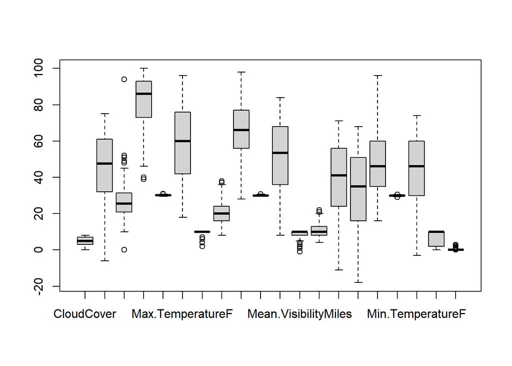

```r
boxplot(cleaned_weather[, 3:22])
```

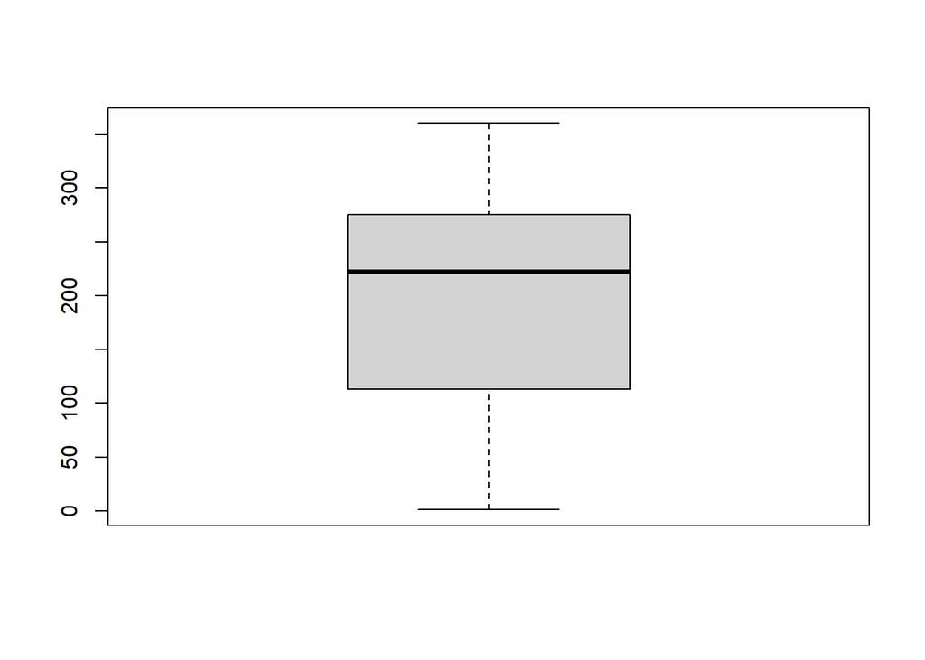

```r
boxplot(cleaned_weather[,23])
```

# Task 4

### function + dplyr

Instructions are to do the same as for task 1 but by using dplyr functions.